# **Facial Emotion Detection**

### **Model Building**

- Try building a layer with 5 Convolutional Blocks and see if performance increases.

```python
# Importing necessary modules for building a Convolutional Neural Network
from tensorflow.keras.models import Sequential
from tensorflow.keras.layers import Conv2D, MaxPooling2D, Flatten, Dense, Dropout, BatchNormalization

# Defining a function to create a more complex CNN architecture
def create_complex_cnn(input_shape=(128, 128, 1)):
    model = Sequential()

    # First convolutional block: Conv2D -> BatchNormalization -> MaxPooling
    model.add(Conv2D(32, (3, 3), activation='relu', input_shape=input_shape))  # 32 filters, 3x3 kernel
    model.add(BatchNormalization())  # Normalize the activations
    model.add(MaxPooling2D(pool_size=(2, 2)))  # Reduce spatial dimensions

    # Second convolutional block: Conv2D -> BatchNormalization -> MaxPooling
    model.add(Conv2D(64, (3, 3), activation='relu'))  # 64 filters
    model.add(BatchNormalization())  # Normalize the activations
    model.add(MaxPooling2D(pool_size=(2, 2)))  # Reduce spatial dimensions

    # Third convolutional block: Conv2D -> BatchNormalization -> MaxPooling
    model.add(Conv2D(128, (3, 3), activation='relu'))  # 128 filters
    model.add(BatchNormalization())  # Normalize the activations
    model.add(MaxPooling2D(pool_size=(2, 2)))  # Reduce spatial dimensions

    # Fourth convolutional block: Conv2D -> BatchNormalization -> MaxPooling
    model.add(Conv2D(256, (3, 3), activation='relu'))  # 256 filters
    model.add(BatchNormalization())  # Normalize the activations
    model.add(MaxPooling2D(pool_size=(2, 2)))  # Reduce spatial dimensions

    # Fifth convolutional block: Conv2D -> BatchNormalization -> MaxPooling
    model.add(Conv2D(512, (3, 3), activation='relu'))  # 512 filters
    model.add(BatchNormalization())  # Normalize the activations
    model.add(MaxPooling2D(pool_size=(2, 2)))  # Reduce spatial dimensions

    # Flatten the feature maps into a single vector
    model.add(Flatten())

    # First dense layer with 512 neurons and dropout for regularization
    model.add(Dense(512, activation='relu'))
    model.add(Dropout(0.5))  # Reduce overfitting

    # Second dense layer with 256 neurons and dropout
    model.add(Dense(256, activation='relu'))
    model.add(Dropout(0.5))  # Additional regularization

    # Output layer with 4 neurons for the 4 classes and softmax activation
    model.add(Dense(4, activation='softmax'))

    return model

# Creating the complex CNN model for grayscale images
input_shape = (128, 128, 1)  # Input shape for grayscale images
complex_cnn = create_complex_cnn(input_shape)

# Displaying the architecture of the complex CNN
complex_cnn.summary()
```

```
Model: "sequential_4"
```

```
┏━━━━━━━━━━━━━━━━━━━━━━━━━━━━━━━━━━━━━━┳━━━━━━━━━━━━━━━━━━━━━━━━━━━━━┳━━━━━━━━━━━━━━━━━┓
┃ Layer (type)                         ┃ Output Shape                ┃         Param # ┃
┡━━━━━━━━━━━━━━━━━━━━━━━━━━━━━━━━━━━━━━╇━━━━━━━━━━━━━━━━━━━━━━━━━━━━━╇━━━━━━━━━━━━━━━━━┩
│ conv2d_14 (Conv2D)                   │ (None, 126, 126, 32)        │             320 │
├──────────────────────────────────────┼─────────────────────────────┼─────────────────┤
│ batch_normalization_14               │ (None, 126, 126, 32)        │             128 │
│ (BatchNormalization)                 │                             │                 │
├──────────────────────────────────────┼─────────────────────────────┼─────────────────┤
│ max_pooling2d_17 (MaxPooling2D)      │ (None, 63, 63, 32)          │               0 │
├──────────────────────────────────────┼─────────────────────────────┼─────────────────┤
│ conv2d_15 (Conv2D)                   │ (None, 61, 61, 64)          │          18,496 │
├──────────────────────────────────────┼─────────────────────────────┼─────────────────┤
│ batch_normalization_15               │ (None, 61, 61, 64)          │             256 │
│ (BatchNormalization)                 │                             │                 │
├──────────────────────────────────────┼─────────────────────────────┼─────────────────┤
│ max_pooling2d_18 (MaxPooling2D)      │ (None, 30, 30, 64)          │               0 │
├──────────────────────────────────────┼─────────────────────────────┼─────────────────┤
│ conv2d_16 (Conv2D)                   │ (None, 28, 28, 128)         │          73,856 │
├──────────────────────────────────────┼─────────────────────────────┼─────────────────┤
│ batch_normalization_16               │ (None, 28, 28, 128)         │             512 │
│ (BatchNormalization)                 │                             │                 │
├──────────────────────────────────────┼─────────────────────────────┼─────────────────┤
│ max_pooling2d_19 (MaxPooling2D)      │ (None, 14, 14, 128)         │               0 │
├──────────────────────────────────────┼─────────────────────────────┼─────────────────┤
│ conv2d_17 (Conv2D)                   │ (None, 12, 12, 256)         │         295,168 │
├──────────────────────────────────────┼─────────────────────────────┼─────────────────┤
│ batch_normalization_17               │ (None, 12, 12, 256)         │           1,024 │
│ (BatchNormalization)                 │                             │                 │
├──────────────────────────────────────┼─────────────────────────────┼─────────────────┤
│ max_pooling2d_20 (MaxPooling2D)      │ (None, 6, 6, 256)           │               0 │
├──────────────────────────────────────┼─────────────────────────────┼─────────────────┤
│ conv2d_18 (Conv2D)                   │ (None, 4, 4, 512)           │       1,180,160 │
├──────────────────────────────────────┼─────────────────────────────┼─────────────────┤
│ batch_normalization_18               │ (None, 4, 4, 512)           │           2,048 │
│ (BatchNormalization)                 │                             │                 │
├──────────────────────────────────────┼─────────────────────────────┼─────────────────┤
│ max_pooling2d_21 (MaxPooling2D)      │ (None, 2, 2, 512)           │               0 │
├──────────────────────────────────────┼─────────────────────────────┼─────────────────┤
│ flatten_10 (Flatten)                 │ (None, 2048)                │               0 │
├──────────────────────────────────────┼─────────────────────────────┼─────────────────┤
│ dense_28 (Dense)                     │ (None, 512)                 │       1,049,088 │
├──────────────────────────────────────┼─────────────────────────────┼─────────────────┤
│ dropout_18 (Dropout)                 │ (None, 512)                 │               0 │
├──────────────────────────────────────┼─────────────────────────────┼─────────────────┤
│ dense_29 (Dense)                     │ (None, 256)                 │         131,328 │
├──────────────────────────────────────┼─────────────────────────────┼─────────────────┤
│ dropout_19 (Dropout)                 │ (None, 256)                 │               0 │
├──────────────────────────────────────┼─────────────────────────────┼─────────────────┤
│ dense_30 (Dense)                     │ (None, 4)                   │           1,028 │
└──────────────────────────────────────┴─────────────────────────────┴─────────────────┘
```

```
 Total params: 2,753,412 (10.50 MB)
```

```
 Trainable params: 2,751,428 (10.50 MB)
```

```
 Non-trainable params: 1,984 (7.75 KB)
```

### **Compiling and Training the Model**

```python
# Compiling the complex CNN model
# Using Adam optimizer for adaptive learning, categorical crossentropy for multi-class classification,
# and accuracy as the metric to monitor performance during training
complex_cnn.compile(
    optimizer='adam',                  # Optimizer for adjusting model weights
    loss='categorical_crossentropy',   # Loss function suitable for multi-class classification
    metrics=['accuracy']               # Metric to evaluate the model's performance
)

# Training the complex CNN model
# Feeding the model with the grayscale training data and validating it on the validation set
history = complex_cnn.fit(
    train_gen_gray,                          # Training data generator for grayscale images
    steps_per_epoch=train_gen_gray.samples // train_gen_gray.batch_size,  # Number of training batches per epoch
    validation_data=val_gen_gray,            # Validation data generator
    validation_steps=val_gen_gray.samples // val_gen_gray.batch_size,  # Number of validation batches per epoch
    epochs=20                                # Number of epochs for training (can be adjusted based on needs)
)
```

```
472/472 ━━━━━━━━━━━━━━━━━━━━ 189s 395ms/step - accuracy: 0.2861 - loss: 1.9930 - val_accuracy: 0.3540 - val_loss: 1.3073
472/472 ━━━━━━━━━━━━━━━━━━━━ 0s 137us/step - accuracy: 0.4688 - loss: 1.4218 - val_accuracy: 0.2353 - val_loss: 1.2279
472/472 ━━━━━━━━━━━━━━━━━━━━ 186s 394ms/step - accuracy: 0.3335 - loss: 1.3399 - val_accuracy: 0.3649 - val_loss: 1.4683
472/472 ━━━━━━━━━━━━━━━━━━━━ 0s 128us/step - accuracy: 0.2500 - loss: 1.2318 - val_accuracy: 0.1176 - val_loss: 1.6032
472/472 ━━━━━━━━━━━━━━━━━━━━ 186s 394ms/step - accuracy: 0.3933 - loss: 1.2524 - val_accuracy: 0.2756 - val_loss: 1.5941
472/472 ━━━━━━━━━━━━━━━━━━━━ 0s 122us/step - accuracy: 0.4062 - loss: 1.1441 - val_accuracy: 0.0588 - val_loss: 1.9828
472/472 ━━━━━━━━━━━━━━━━━━━━ 186s 394ms/step - accuracy: 0.4543 - loss: 1.1813 - val_accuracy: 0.3776 - val_loss: 2.1767
472/472 ━━━━━━━━━━━━━━━━━━━━ 0s 110us/step - accuracy: 0.5000 - loss: 0.9892 - val_accuracy: 0.2941 - val_loss: 2.5041
472/472 ━━━━━━━━━━━━━━━━━━━━ 185s 392ms/step - accuracy: 0.5074 - loss: 1.0953 - val_accuracy: 0.5224 - val_loss: 1.0294
472/472 ━━━━━━━━━━━━━━━━━━━━ 0s 103us/step - accuracy: 0.5312 - loss: 1.1753 - val_accuracy: 0.4118 - val_loss: 1.1725
472/472 ━━━━━━━━━━━━━━━━━━━━ 184s 390ms/step - accuracy: 0.5543 - loss: 1.0209 - val_accuracy: 0.5946 - val_loss: 0.9017
472/472 ━━━━━━━━━━━━━━━━━━━━ 0s 124us/step - accuracy: 0.5938 - loss: 0.9582 - val_accuracy: 0.5882 - val_loss: 1.0215
472/472 ━━━━━━━━━━━━━━━━━━━━ 185s 392ms/step - accuracy: 0.5917 - loss: 0.9760 - val_accuracy: 0.3964 - val_loss: 1.3073
472/472 ━━━━━━━━━━━━━━━━━━━━ 0s 119us/step - accuracy: 0.4688 - loss: 1.0901 - val_accuracy: 0.4706 - val_loss: 1.2492
472/472 ━━━━━━━━━━━━━━━━━━━━ 188s 398ms/step - accuracy: 0.6012 - loss: 0.9399 - val_accuracy: 0.5935 - val_loss: 0.9441
472/472 ━━━━━━━━━━━━━━━━━━━━ 0s 109us/step - accuracy: 0.6250 - loss: 0.8289 - val_accuracy: 0.7059 - val_loss: 0.8192
472/472 ━━━━━━━━━━━━━━━━━━━━ 187s 395ms/step - accuracy: 0.6231 - loss: 0.9228 - val_accuracy: 0.6821 - val_loss: 0.8200
472/472 ━━━━━━━━━━━━━━━━━━━━ 0s 124us/step - accuracy: 0.6875 - loss: 0.5912 - val_accuracy: 0.7647 - val_loss: 0.7026
472/472 ━━━━━━━━━━━━━━━━━━━━ 186s 393ms/step - accuracy: 0.6401 - loss: 0.8925 - val_accuracy: 0.6639 - val_loss: 0.8264
472/472 ━━━━━━━━━━━━━━━━━━━━ 0s 129us/step - accuracy: 0.6562 - loss: 0.7580 - val_accuracy: 0.3529 - val_loss: 1.1410
```

### **Evaluating the Model on Test Set**

```
4/4 ━━━━━━━━━━━━━━━━━━━━ 0s 78ms/step - accuracy: 0.6490 - loss: 0.7707
Test Loss: 0.8268
Test Accuracy: 62.50%
```

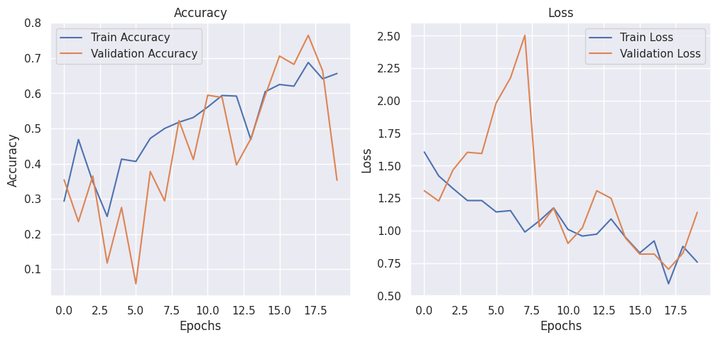

```python
# Evaluating the complex CNN model on the test set
# This calculates the model's loss and accuracy on unseen test data
test_loss, test_accuracy = complex_cnn.evaluate(
    test_gen_gray,                                   # Test data generator for grayscale images
    steps=test_gen_gray.samples // test_gen_gray.batch_size  # Number of test batches
)

# Displaying the test loss and accuracy
print(f"Test Loss: {test_loss:.4f}")              # Print test loss rounded to 4 decimal places
print(f"Test Accuracy: {test_accuracy * 100:.2f}%")  # Print test accuracy as a percentage

# Importing the required library for visualization
import matplotlib.pyplot as plt

# Plotting training and validation accuracy
plt.figure(figsize=(12, 5))  # Setting the figure size

# Subplot for accuracy
plt.subplot(1, 2, 1)  # 1 row, 2 columns, position 1
plt.plot(history.history['accuracy'], label='Train Accuracy')  # Training accuracy
plt.plot(history.history['val_accuracy'], label='Validation Accuracy')  # Validation accuracy
plt.title('Accuracy')  # Setting the title
plt.xlabel('Epochs')  # Label for x-axis
plt.ylabel('Accuracy')  # Label for y-axis
plt.legend()  # Add legend to differentiate training and validation accuracy

# Subplot for loss
plt.subplot(1, 2, 2)  # 1 row, 2 columns, position 2
plt.plot(history.history['loss'], label='Train Loss')  # Training loss
plt.plot(history.history['val_loss'], label='Validation Loss')  # Validation loss
plt.title('Loss')  # Setting the title
plt.xlabel('Epochs')  # Label for x-axis
plt.ylabel('Loss')  # Label for y-axis
plt.legend()  # Add legend to differentiate training and validation loss

# Displaying the plots
plt.show()
```

**Observations and Insights:__**

### **Plotting the Confusion Matrix for the chosen final model**

```
4/4 ━━━━━━━━━━━━━━━━━━━━ 1s 87ms/step
```

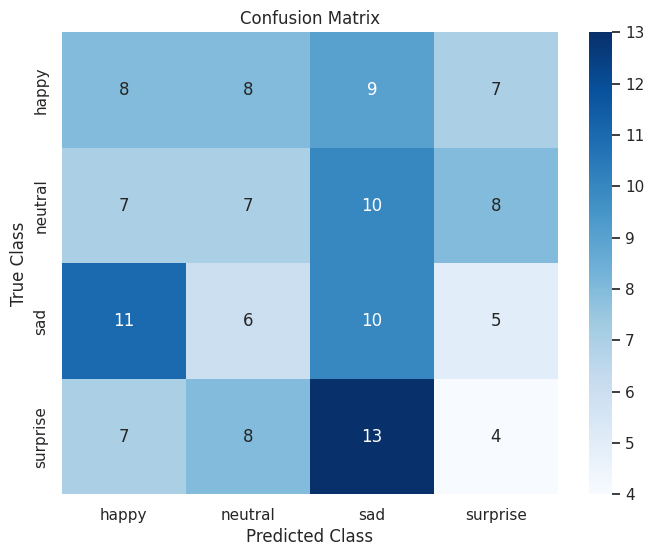

```python
import numpy as np

# Reset the test generator to ensure correct alignment between data and predictions
test_gen_gray.reset()

# Get predictions for the test set
predictions = complex_cnn.predict(
    test_gen_gray,
    steps=test_gen_gray.samples // test_gen_gray.batch_size
)

# Convert predicted probabilities to class indices
predicted_classes = np.argmax(predictions, axis=1)

# Get true class labels from the test generator
true_classes = test_gen_gray.classes

# Class labels
class_labels = list(test_gen_gray.class_indices.keys())
from sklearn.metrics import confusion_matrix
import seaborn as sns
import matplotlib.pyplot as plt

# Compute the confusion matrix
conf_matrix = confusion_matrix(true_classes, predicted_classes)

# Plot the confusion matrix
plt.figure(figsize=(8, 6))
sns.heatmap(conf_matrix, annot=True, fmt='d', cmap='Blues', xticklabels=class_labels, yticklabels=class_labels)
plt.title("Confusion Matrix")
plt.xlabel("Predicted Class")
plt.ylabel("True Class")
plt.show()
```

**Observations and Insights:__**

## **Conclusion:____________**

### **Refined insights**:

- What are the most meaningful insights from the data relevant to the problem?

### **Comparison of various techniques and their relative performance**:

- How do different techniques perform? Which one is performing relatively better? Is there scope to improve the performance further?

### **Proposal for the final solution design**:

- What model do you propose to be adopted? Why is this the best solution to adopt?